# Defining the Research Problem

## Specifying the Research Question

The goal of this analysis is to predict individuals who are most likely to click on a cryptography course advertisement. This project uses R for analysis.

## Defining the Metric for Success

The project will be considered a success when we are able to clean and analyse past data to segment blog users and predict individuals who should be targeted for an advertisement.

## Understanding the Context

A Kenyan entrepreneur has created an online cryptography course and would want to advertise it on her blog. She currently targets audiences originating from various countries. In the past, she ran ads to advertise a related course on the same blog and collected data in the process. She has employed my services as a Data Science Consultant to help her identify which individuals are most likely to click on her ads.

## Recording the Exprimental Design

Below are the steps that will be followed in this analysis in order to respond to the research question satisfactorily:

> - Read the Data
> - Check the Data
> - Data Cleaning
> - Univariate Analysis
> - Bivariate Analysis
> - Implementing the Solution (Modeling)
> - Conclusion and Recommendation

## Data Relevance

The data used for the project was collected from a prior advertisement for a similar course on the same platform. The dataset contains 10 attributes and 1,000 records. These attributes contain descriptive information of past blog users. Some of the attributes include country, age and gender of the user among others.

# Importing Relevant Libraries

```python
# Installing data.table package
install.packages("data.table", dependencies=TRUE)
```

# Reading the Data

```python
# Reading the data into R from the csv file

library(data.table)
ad <- read.csv('advertising.csv')
head(ad)
```

A data.frame: 6 × 10

|  | Daily.Time.Spent.on.Site <dbl> | Age <int> | Area.Income <dbl> | Daily.Internet.Usage <dbl> | Ad.Topic.Line <chr> | City <chr> | Male <int> | Country <chr> | Timestamp <chr> | Clicked.on.Ad <int> |
| --- | --- | --- | --- | --- | --- | --- | --- | --- | --- | --- |
| 1 | 68.95 | 35 | 61833.90 | 256.09 | Cloned 5thgeneration orchestration | Wrightburgh | 0 | Tunisia | 2016-03-27 00:53:11 | 0 |
| 2 | 80.23 | 31 | 68441.85 | 193.77 | Monitored national standardization | West Jodi | 1 | Nauru | 2016-04-04 01:39:02 | 0 |
| 3 | 69.47 | 26 | 59785.94 | 236.50 | Organic bottom-line service-desk | Davidton | 0 | San Marino | 2016-03-13 20:35:42 | 0 |
| 4 | 74.15 | 29 | 54806.18 | 245.89 | Triple-buffered reciprocal time-frame | West Terrifurt | 1 | Italy | 2016-01-10 02:31:19 | 0 |
| 5 | 68.37 | 35 | 73889.99 | 225.58 | Robust logistical utilization | South Manuel | 0 | Iceland | 2016-06-03 03:36:18 | 0 |
| 6 | 59.99 | 23 | 59761.56 | 226.74 | Sharable client-driven software | Jamieberg | 1 | Norway | 2016-05-19 14:30:17 | 0 |

# Checking the Data

```python
# Checking the top 6 records

head(ad)
```

A data.frame: 6 × 10

|  | Daily.Time.Spent.on.Site <dbl> | Age <int> | Area.Income <dbl> | Daily.Internet.Usage <dbl> | Ad.Topic.Line <chr> | City <chr> | Male <int> | Country <chr> | Timestamp <chr> | Clicked.on.Ad <int> |
| --- | --- | --- | --- | --- | --- | --- | --- | --- | --- | --- |
| 1 | 68.95 | 35 | 61833.90 | 256.09 | Cloned 5thgeneration orchestration | Wrightburgh | 0 | Tunisia | 2016-03-27 00:53:11 | 0 |
| 2 | 80.23 | 31 | 68441.85 | 193.77 | Monitored national standardization | West Jodi | 1 | Nauru | 2016-04-04 01:39:02 | 0 |
| 3 | 69.47 | 26 | 59785.94 | 236.50 | Organic bottom-line service-desk | Davidton | 0 | San Marino | 2016-03-13 20:35:42 | 0 |
| 4 | 74.15 | 29 | 54806.18 | 245.89 | Triple-buffered reciprocal time-frame | West Terrifurt | 1 | Italy | 2016-01-10 02:31:19 | 0 |
| 5 | 68.37 | 35 | 73889.99 | 225.58 | Robust logistical utilization | South Manuel | 0 | Iceland | 2016-06-03 03:36:18 | 0 |
| 6 | 59.99 | 23 | 59761.56 | 226.74 | Sharable client-driven software | Jamieberg | 1 | Norway | 2016-05-19 14:30:17 | 0 |

```python
# Checking the bottom 6 records

tail(ad)
```

A data.frame: 6 × 10

|  | Daily.Time.Spent.on.Site <dbl> | Age <int> | Area.Income <dbl> | Daily.Internet.Usage <dbl> | Ad.Topic.Line <chr> | City <chr> | Male <int> | Country <chr> | Timestamp <chr> | Clicked.on.Ad <int> |
| --- | --- | --- | --- | --- | --- | --- | --- | --- | --- | --- |
| 995 | 43.70 | 28 | 63126.96 | 173.01 | Front-line bifurcated ability | Nicholasland | 0 | Mayotte | 2016-04-04 03:57:48 | 1 |
| 996 | 72.97 | 30 | 71384.57 | 208.58 | Fundamental modular algorithm | Duffystad | 1 | Lebanon | 2016-02-11 21:49:00 | 1 |
| 997 | 51.30 | 45 | 67782.17 | 134.42 | Grass-roots cohesive monitoring | New Darlene | 1 | Bosnia and Herzegovina | 2016-04-22 02:07:01 | 1 |
| 998 | 51.63 | 51 | 42415.72 | 120.37 | Expanded intangible solution | South Jessica | 1 | Mongolia | 2016-02-01 17:24:57 | 1 |
| 999 | 55.55 | 19 | 41920.79 | 187.95 | Proactive bandwidth-monitored policy | West Steven | 0 | Guatemala | 2016-03-24 02:35:54 | 0 |
| 1000 | 45.01 | 26 | 29875.80 | 178.35 | Virtual 5thgeneration emulation | Ronniemouth | 0 | Brazil | 2016-06-03 21:43:21 | 1 |

```python
# Checking the total number of records

nrow(ad)
```

1000

```python
# Checking the total number of columns

ncol(ad)
```

10

```python
# Checking all column names

names(ad)
```

1. 'Daily.Time.Spent.on.Site'

2. 'Age'

3. 'Area.Income'

4. 'Daily.Internet.Usage'

5. 'Ad.Topic.Line'

6. 'City'

7. 'Male'

8. 'Country'

9. 'Timestamp'

10. 'Clicked.on.Ad'

```python
# Checking the data types of each column

str(ad)
```

```
'data.frame':	1000 obs. of  10 variables:
 $ Daily.Time.Spent.on.Site: num  69 80.2 69.5 74.2 68.4 ...
 $ Age                     : int  35 31 26 29 35 23 33 48 30 20 ...
 $ Area.Income             : num  61834 68442 59786 54806 73890 ...
 $ Daily.Internet.Usage    : num  256 194 236 246 226 ...
 $ Ad.Topic.Line           : chr  "Cloned 5thgeneration orchestration" "Monitored national standardization" "Organic bottom-line service-desk" "Triple-buffered reciprocal time-frame" ...
 $ City                    : chr  "Wrightburgh" "West Jodi" "Davidton" "West Terrifurt" ...
 $ Male                    : int  0 1 0 1 0 1 0 1 1 1 ...
 $ Country                 : chr  "Tunisia" "Nauru" "San Marino" "Italy" ...
 $ Timestamp               : chr  "2016-03-27 00:53:11" "2016-04-04 01:39:02" "2016-03-13 20:35:42" "2016-01-10 02:31:19" ...
 $ Clicked.on.Ad           : int  0 0 0 0 0 0 0 1 0 0 ...
```

```python
# Checking the number of unique values in each column

lengths(lapply(ad, unique))
```

**Daily.Time.Spent.on.Site**

900

**Age**

43

**Area.Income**

1000

**Daily.Internet.Usage**

966

**Ad.Topic.Line**

1000

**City**

969

**Male**

2

**Country**

237

**Timestamp**

1000

**Clicked.on.Ad**

2

- There are 969 unique cities and 237 unique countries in the dataset.
- There are only 43 unique ages in the dataset.

```python
# Checking the summary of the data

summary(ad)
```

```
 Daily.Time.Spent.on.Site      Age         Area.Income    Daily.Internet.Usage
 Min.   :32.60            Min.   :19.00   Min.   :13996   Min.   :104.8
 1st Qu.:51.36            1st Qu.:29.00   1st Qu.:47032   1st Qu.:138.8
 Median :68.22            Median :35.00   Median :57012   Median :183.1
 Mean   :65.00            Mean   :36.01   Mean   :55000   Mean   :180.0
 3rd Qu.:78.55            3rd Qu.:42.00   3rd Qu.:65471   3rd Qu.:218.8
 Max.   :91.43            Max.   :61.00   Max.   :79485   Max.   :270.0
 Ad.Topic.Line          City                Male         Country
 Length:1000        Length:1000        Min.   :0.000   Length:1000
 Class :character   Class :character   1st Qu.:0.000   Class :character
 Mode  :character   Mode  :character   Median :0.000   Mode  :character
                                       Mean   :0.481
                                       3rd Qu.:1.000
                                       Max.   :1.000
  Timestamp         Clicked.on.Ad
 Length:1000        Min.   :0.0
 Class :character   1st Qu.:0.0
 Mode  :character   Median :0.5
                    Mean   :0.5
                    3rd Qu.:1.0
                    Max.   :1.0
```

# Data Cleaning

Missing Data

```python
# Checking the existence of missing values

colSums(is.na(ad))
```

**Daily.Time.Spent.on.Site**

0

**Age**

0

**Area.Income**

0

**Daily.Internet.Usage**

0

**Ad.Topic.Line**

0

**City**

0

**Male**

0

**Country**

0

**Timestamp**

0

**Clicked.on.Ad**

0

- No missing values in any columns of the dataframe

Outliers

```python
# creating a variable with only numeric columns

library(tidyverse)
my_data <- ad %>% select(1,2,3,4,7,10)
```

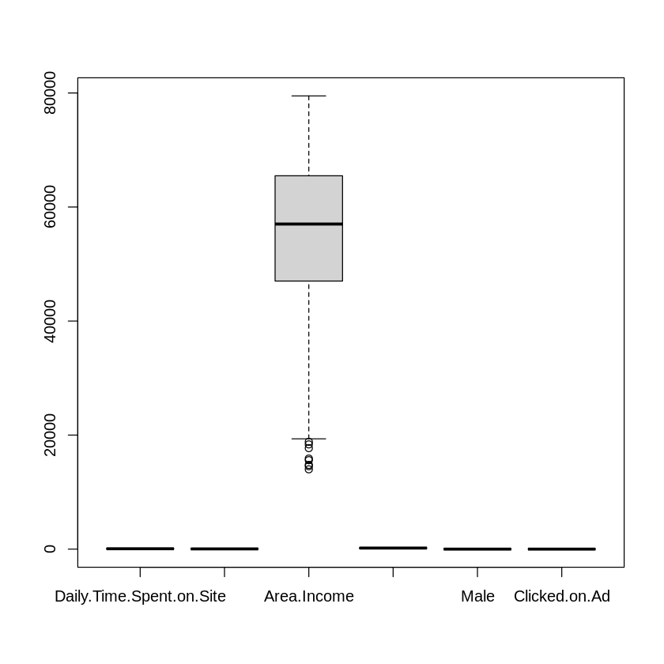

```python
# Previewing outliers for numeric columns using boxplots

boxplot(my_data)
```

- We see that 'area income' is the only attribute with outliers. We shall investigate each column individually for further analysis.

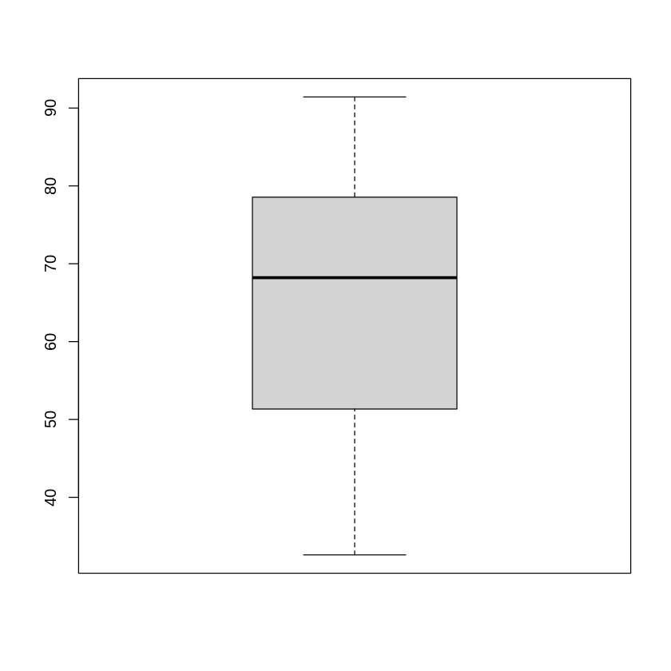

```python
# Boxplot for daily time spent variable

boxplot(ad$Daily.Time.Spent.on.Site)
```

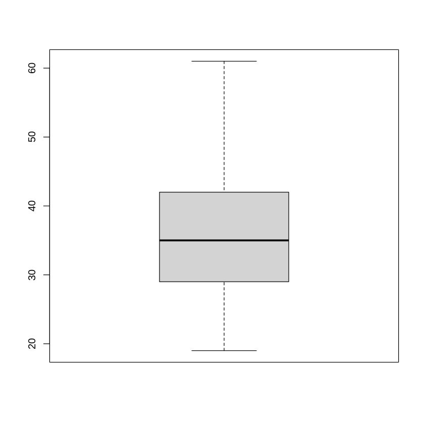

```python
# Boxplot for age variable

boxplot(ad$Age)
```

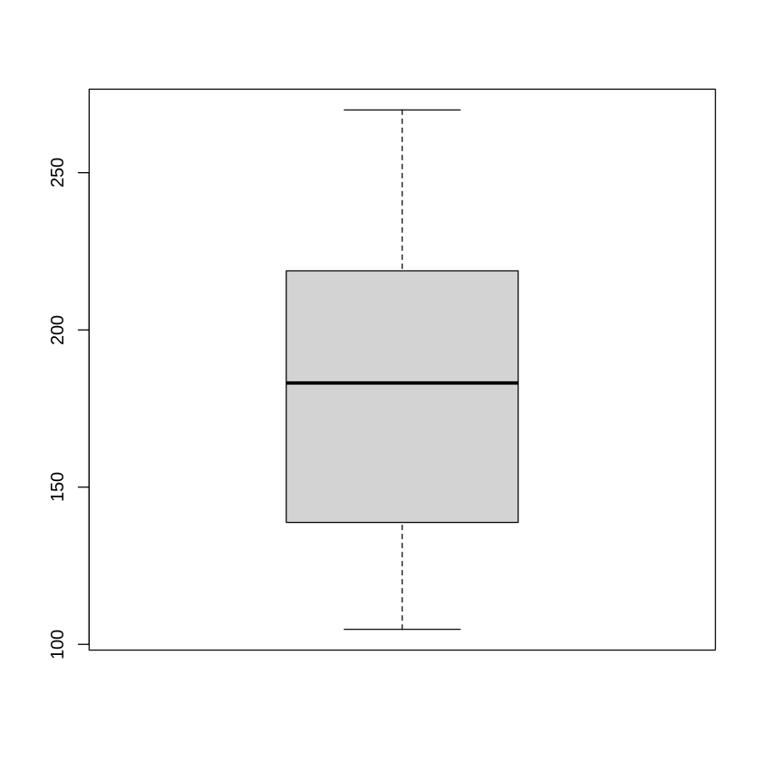

```python
# Boxplot for daily internet usage variable

boxplot(ad$Daily.Internet.Usage)
```

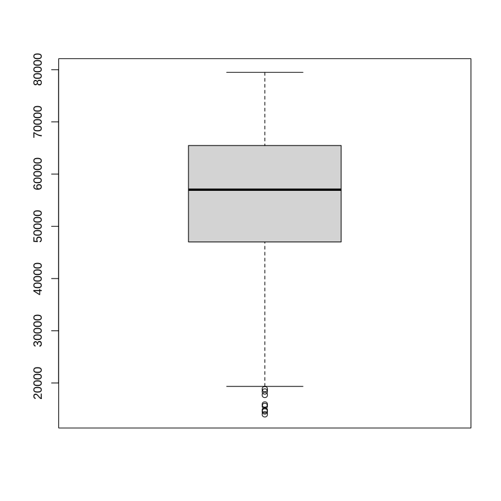

```python
# Boxplot for area income variable

boxplot(ad$Area.Income)
```

- From the above graphs, no other columns have outliers except the 'area income' attribute.

```python
# Displaying all outliers in the income column

boxplot.stats(ad$Area.Income)$out
```

1. 17709.98

2. 18819.34

3. 15598.29

4. 15879.1

5. 14548.06

6. 13996.5

7. 14775.5

8. 18368.57

```python
# Checking the countries associated with outlier incomes

ad$Country[ad$Area.Income %in% c(17709.98, 18819.34, 15598.29, 15879.1, 14548.06, 13996.5, 14775.5, 18368.57)]
```

1. 'Belize'

2. 'Algeria'

3. 'Azerbaijan'

4. 'Tajikistan'

5. 'Lebanon'

6. 'El Salvador'

7. 'Jersey'

8. 'Luxembourg'

Anomalies

```python
# Checking for duplicate data

duplicated_rows <- ad[duplicated(ad),]
duplicated_rows
```

A data.frame: 0 × 10

| Daily.Time.Spent.on.Site | Age | Area.Income | Daily.Internet.Usage | Ad.Topic.Line | City | Male | Country | Timestamp | Clicked.on.Ad |
| --- | --- | --- | --- | --- | --- | --- | --- | --- | --- |
| <dbl> | <int> | <dbl> | <dbl> | <chr> | <chr> | <int> | <chr> | <chr> | <int> |

- No duplicate records in the dataset

# Exploratory Data Analysis

## Univariate Analysis

- In this section, we will investigate each variable individually. The steps here include calculating and interpreting measures of central tendency (mode, median, mean) as well as computing and explaining the range, the interquartile range, the standard deviation, variance, skewness, and kurtosis

```python
# Calculating the mean for all numeric columns

lapply(my_data,FUN=mean)
```

**$Daily.Time.Spent.on.Site**

65.0002

**$Age**

36.009

**$Area.Income**

55000.00008

**$Daily.Internet.Usage**

180.0001

**$Male**

0.481

**$Clicked.on.Ad**

0.5

- Average age of the blog users is 36 while the average income is 55,000.

```python
# Calculating the median for all numeric columns

lapply(my_data,FUN=median)
```

**$Daily.Time.Spent.on.Site**

68.215

**$Age**

35

**$Area.Income**

57012.3

**$Daily.Internet.Usage**

183.13

**$Male**

0

**$Clicked.on.Ad**

0.5

```python
# Calculating the mode for all numeric columns

getmode <- function(v) {
   uniqv <- unique(v)
   uniqv[which.max(tabulate(match(v, uniqv)))]
}
lapply(my_data,FUN=getmode)
```

**$Daily.Time.Spent.on.Site**

62.26

**$Age**

31

**$Area.Income**

61833.9

**$Daily.Internet.Usage**

167.22

**$Male**

0

**$Clicked.on.Ad**

0

- Most occuring age is 31 and the median age is 35.
- Most occuring gender is female.

```python
# Calculating the minimum value for all numeric columns

lapply(my_data,FUN=min)
```

**$Daily.Time.Spent.on.Site**

32.6

**$Age**

19

**$Area.Income**

13996.5

**$Daily.Internet.Usage**

104.78

**$Male**

0

**$Clicked.on.Ad**

0

```python
# Calculating the maximum value for all numeric columns

lapply(my_data,FUN=max)
```

**$Daily.Time.Spent.on.Site**

91.43

**$Age**

61

**$Area.Income**

79484.8

**$Daily.Internet.Usage**

269.96

**$Male**

1

**$Clicked.on.Ad**

1

- Lowest income is ~14,000 while the highest is ~79,500
- The youngest age is 19 and the oldest blog user's age is 61

```python
# Checking the range for all numeric columns

lapply(my_data,FUN=range)
```

**$Daily.Time.Spent.on.Site**

1. 32.6

2. 91.43

**$Age**

1. 19

2. 61

**$Area.Income**

1. 13996.5

2. 79484.8

**$Daily.Internet.Usage**

1. 104.78

2. 269.96

**$Male**

1. 0

2. 1

**$Clicked.on.Ad**

1. 0

2. 1

```python
# Calculating the quantiles for all numeric columns

lapply(my_data,FUN=quantile)
```

**$Daily.Time.Spent.on.Site**

**0%**

32.6

**25%**

51.36

**50%**

68.215

**75%**

78.5475

**100%**

91.43

**$Age**

**0%**

19

**25%**

29

**50%**

35

**75%**

42

**100%**

61

**$Area.Income**

**0%**

13996.5

**25%**

47031.8025

**50%**

57012.3

**75%**

65470.635

**100%**

79484.8

**$Daily.Internet.Usage**

**0%**

104.78

**25%**

138.83

**50%**

183.13

**75%**

218.7925

**100%**

269.96

**$Male**

**0%**

0

**25%**

0

**50%**

0

**75%**

1

**100%**

1

**$Clicked.on.Ad**

**0%**

0

**25%**

0

**50%**

0.5

**75%**

1

**100%**

1

```python
# Calculating the variance for all numeric columns

lapply(my_data,FUN=var)
```

**$Daily.Time.Spent.on.Site**

251.337094854855

**$Age**

77.1861051051051

**$Area.Income**

179952405.951775

**$Daily.Internet.Usage**

1927.41539618619

**$Male**

0.249888888888889

**$Clicked.on.Ad**

0.25025025025025

```python
# Calculating the standard deviation for all numeric columns

lapply(my_data,FUN=sd)
```

**$Daily.Time.Spent.on.Site**

15.8536145675002

**$Age**

8.78556231012592

**$Area.Income**

13414.6340222824

**$Daily.Internet.Usage**

43.9023393019801

**$Male**

0.499888876540466

**$Clicked.on.Ad**

0.500250187656387

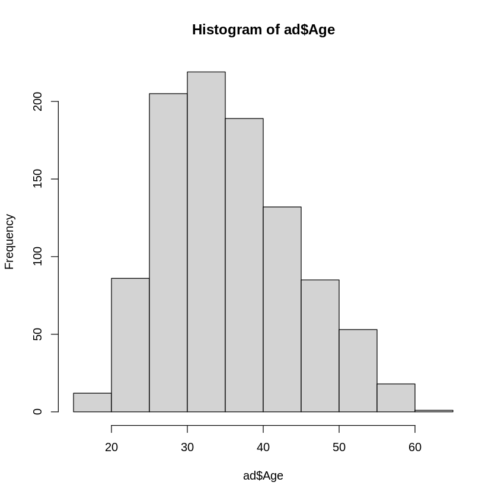

```python
# Plotting a histogram for age variable

hist(ad$Age)
```

- The frequency distribution above depicts a relatively normal distribution for the age attribute. Most individuals' age is centered around the mean.

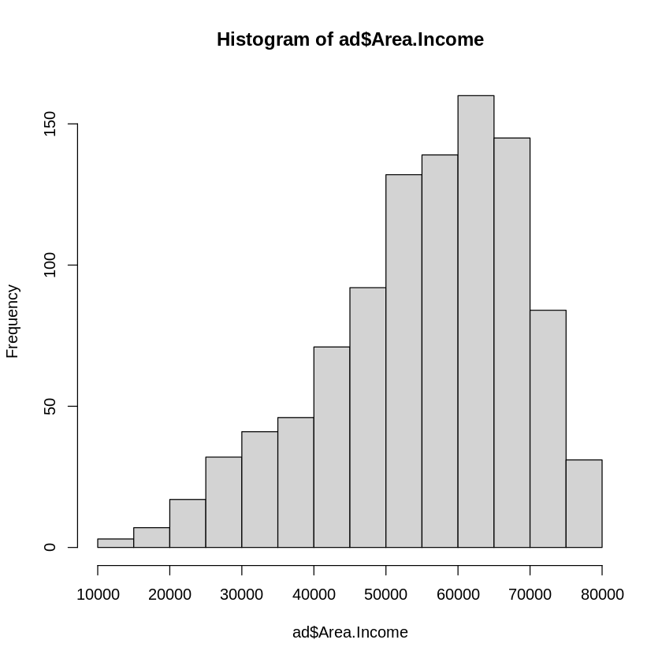

```python
# Plotting a histogram for area income variable

hist(ad$Area.Income)
```

- Income distribution is skewed to the left.

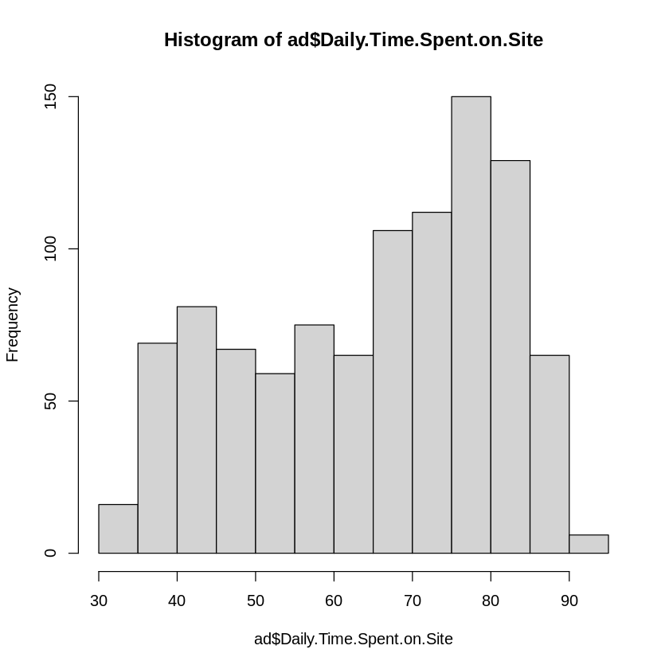

```python
# Plotting a histogram for daily time variable

hist(ad$Daily.Time.Spent.on.Site)
```

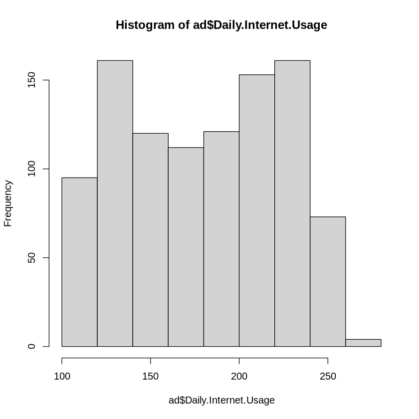

```python
# Plotting a histogram for daily internet variable

hist(ad$Daily.Internet.Usage)
```

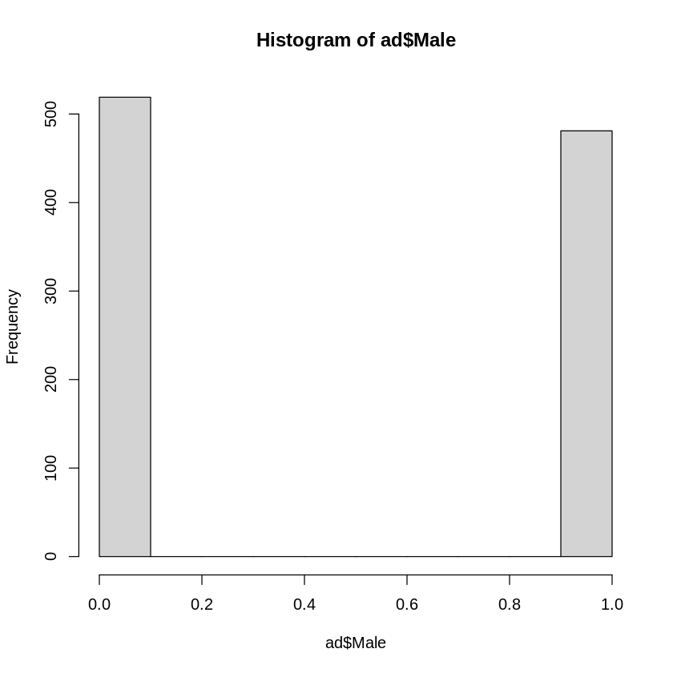

```python
# Plotting a histogram for gender variable

hist(ad$Male)
```

- The number of males and females is fairly balanced.

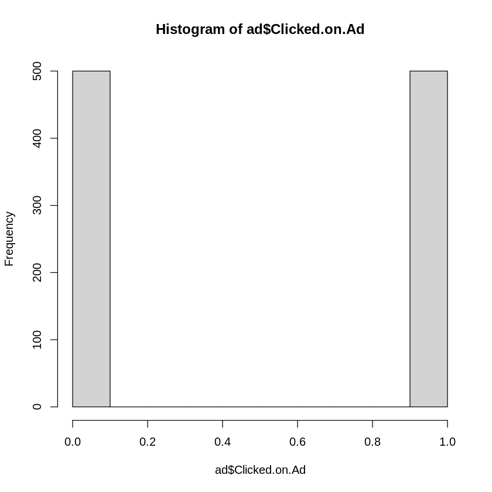

```python
# Plotting a histogram for clicked ad variable

hist(ad$Clicked.on.Ad)
```

- The target variable for this analysis has equal observations for both classes.

```python
# Checking actual number of male vs females

table(ad$Male)
```

```
  0   1
519 481
```

```python
# Confirming distribution of classes

table(ad$Clicked.on.Ad)
```

```
  0   1
500 500
```

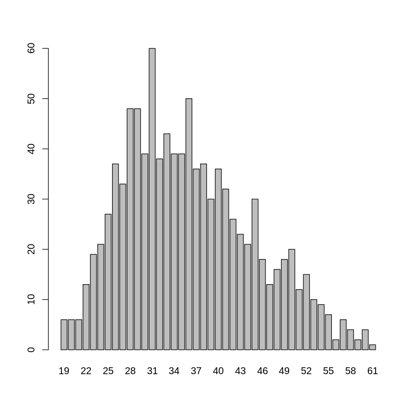

```python
# Bar plot of the age variable

age <- ad$Age
age_freq <- table(age)
barplot(age_freq)
```

```python
# Checking distribution of each country

table(ad$Country)
```

[output not shown]

[output cut: 419 more lines]

```
                                                  6
                                          Venezuela
                                                  7
                                            Vietnam
                                                  3
                                  Wallis and Futuna
                                                  4
                                     Western Sahara
                                                  7
                                              Yemen
                                                  3
                                             Zambia
                                                  4
                                           Zimbabwe
                                                  6
```

## Bivariate Analysis

In this section, we investigate the relationship of different variables by creating relevant visualizations such asscatter plots, correlation matrix and Pearson correlation coefficient.

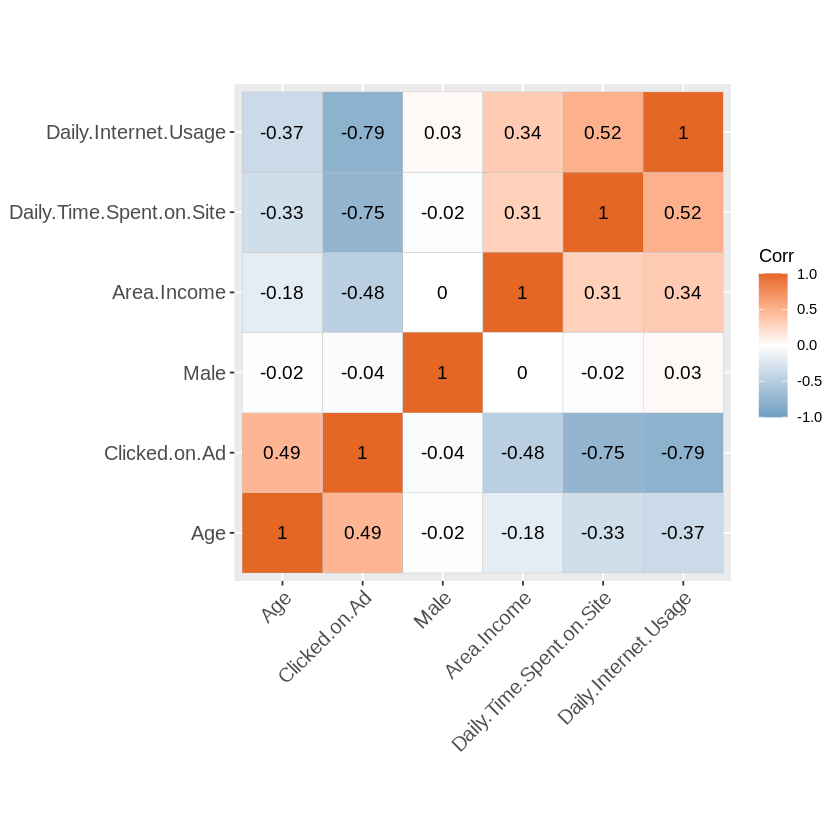

```python
# Checking the correlation coefficients for numeric variables

install.packages("ggcorrplot")
library(ggcorrplot)
corr = round(cor(select_if(my_data, is.numeric)), 2)
ggcorrplot(corr, hc.order = T, ggtheme = ggplot2::theme_gray,
   colors = c("#6D9EC1", "white", "#E46726"), lab = T)
```

- There's a relatively strong negative correlation between daily internet usage, area income, daily time spent on site vs clicked on ad.

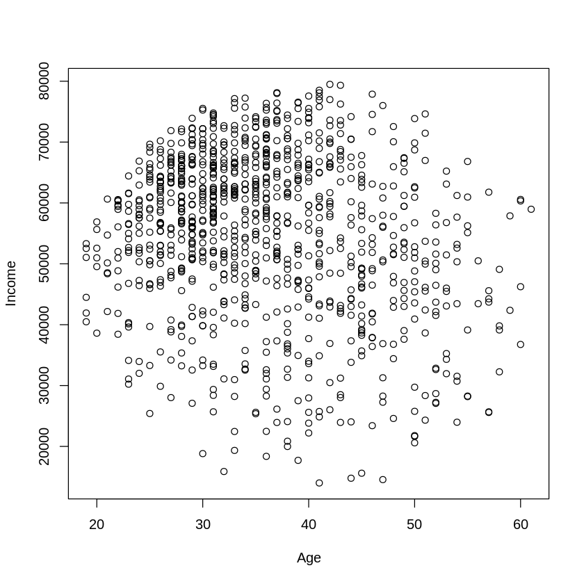

```python
# Scatter plot to compare age vs income

plot(ad$Age, ad$Area.Income, xlab="Age", ylab="Income")
```

- Most high income individuals are between the ages of 30 to 50.

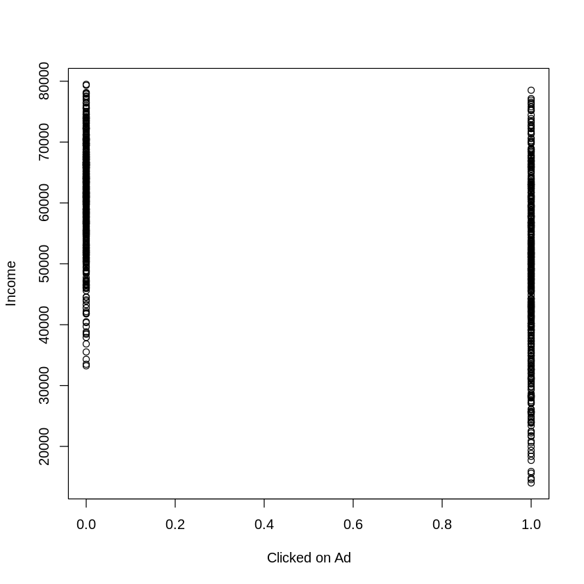

```python
# Scatter plot to compare income vs Clicked on ad

plot(ad$Clicked.on.Ad, ad$Area.Income, xlab="Clicked on Ad", ylab="Income")
```

- Most low income individuals clicked on the ad.

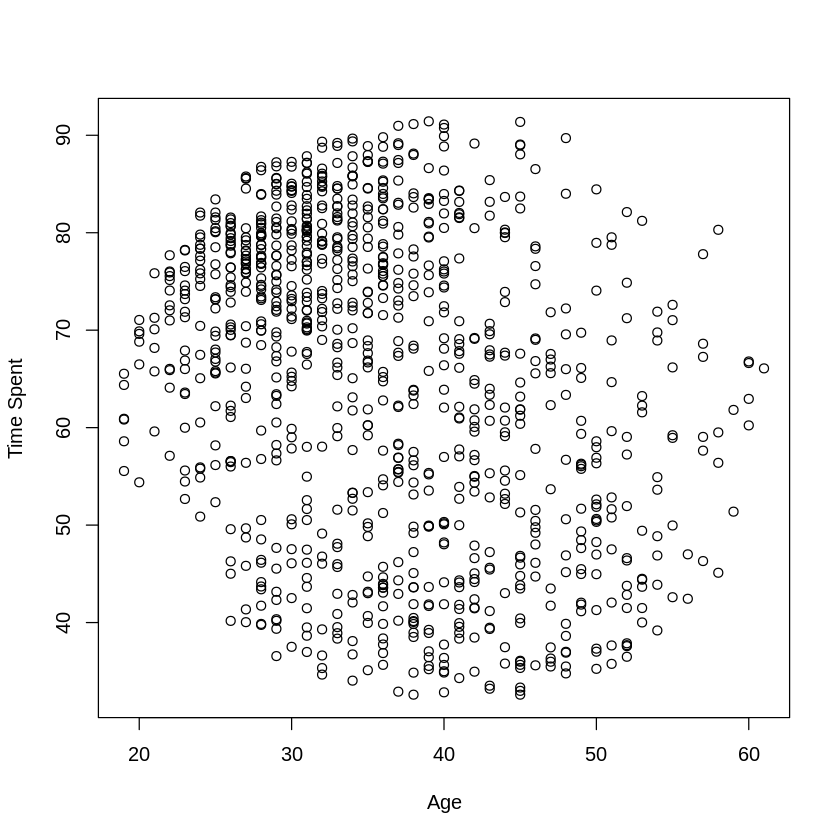

```python
# Scatter plot to compare age vs daily time spent

plot(ad$Age, ad$Daily.Time.Spent.on.Site, xlab="Age", ylab="Time Spent")
```

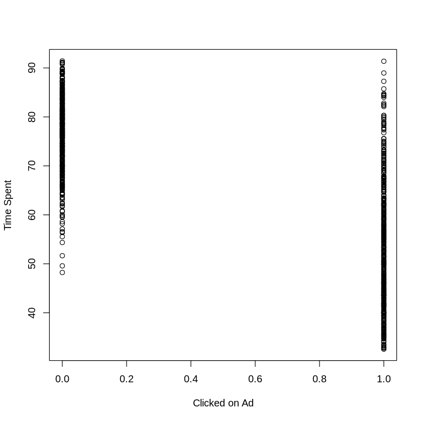

```python
# Scatter plot to compare clicked on ad vs time spent

plot(ad$Clicked.on.Ad, ad$Daily.Time.Spent.on.Site, xlab="Clicked on Ad", ylab="Time Spent")
```

- Most users who spent the least amount of time on the blog clicked on the ad.

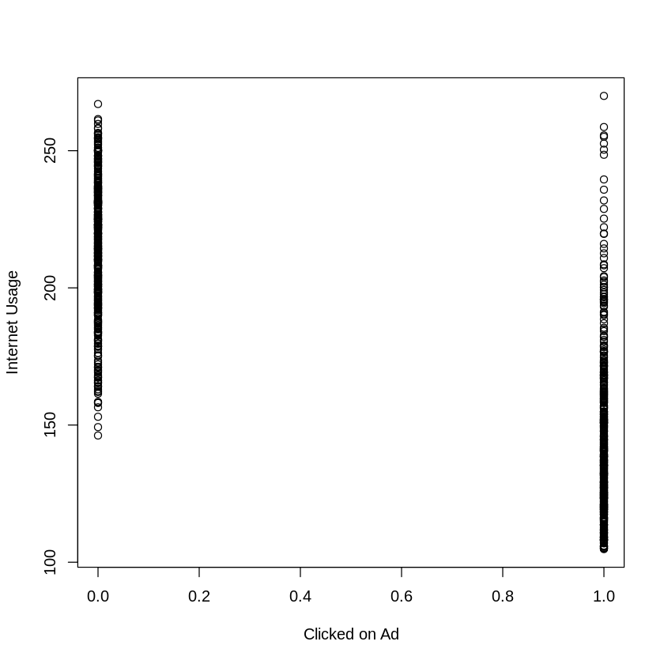

```python
# Scatter plot to compare clicked on ad vs internet usage

plot(ad$Clicked.on.Ad, ad$Daily.Internet.Usage, xlab="Clicked on Ad", ylab="Internet Usage")
```

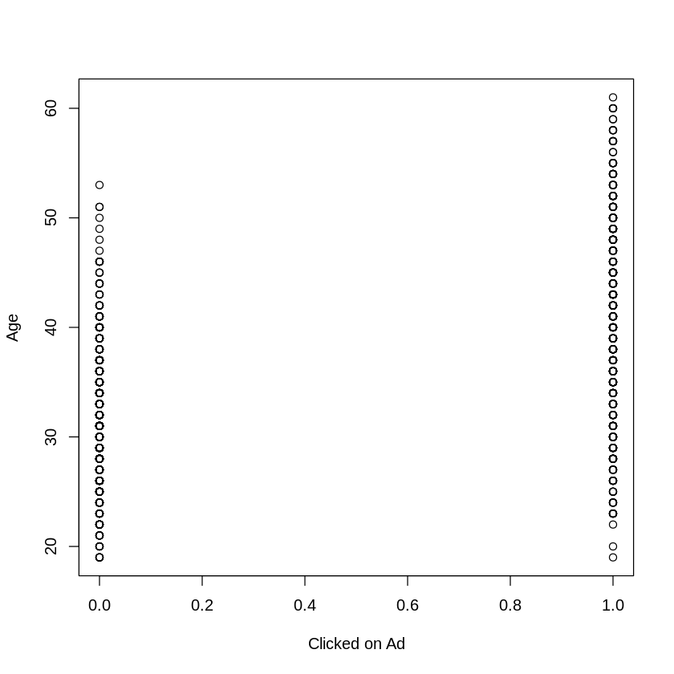

```python
# Scatter plot to compare age vs Clicked on ad

plot(ad$Clicked.on.Ad, ad$`Age`, xlab="Clicked on Ad", ylab="Age")
```

# Implementing the Solution

## Decision Trees

```python
# Importing relevant libraries

install.packages("rpart")
install.packages("rpart.plot")
install.packages("mlbench")
install.packages("caret")

library(rpart)
library(rpart.plot)
library(mlbench)
library(caret)
```

```python
# Defining features and target variables

ad <- ad %>% select(1,2,3,4,7,8,10)

head(ad)
```

A data.frame: 6 × 7

|  | Daily.Time.Spent.on.Site <dbl> | Age <int> | Area.Income <dbl> | Daily.Internet.Usage <dbl> | Male <int> | Country <chr> | Clicked.on.Ad <int> |
| --- | --- | --- | --- | --- | --- | --- | --- |
| 1 | 68.95 | 35 | 61833.90 | 256.09 | 0 | Tunisia | 0 |
| 2 | 80.23 | 31 | 68441.85 | 193.77 | 1 | Nauru | 0 |
| 3 | 69.47 | 26 | 59785.94 | 236.50 | 0 | San Marino | 0 |
| 4 | 74.15 | 29 | 54806.18 | 245.89 | 1 | Italy | 0 |
| 5 | 68.37 | 35 | 73889.99 | 225.58 | 0 | Iceland | 0 |
| 6 | 59.99 | 23 | 59761.56 | 226.74 | 1 | Norway | 0 |

```python
# Converting the country variable to numeric data type

ad$Country <- as.integer(as.factor(ad$Country))
```

```python
# Normalizing relevant features

normalize <- function(x){
  return ((x-min(x)) / (max(x)-min(x)))}

ad$Daily.Time.Spent.on.Site <- normalize(ad$Daily.Time.Spent.on.Site )
ad$Age <- normalize(ad$Age)
ad$Area.Income <- normalize(ad$Area.Income)
ad$Daily.Internet.Usage <- normalize(ad$Daily.Internet.Usage)
ad$Country <- normalize(ad$Country)
```

```python
# Confirming the dimensions of the dataset

dim(ad)
```

1. 1000

2. 7

```python
# Creating the test and train sets. We can do a 800/200 split.

data_train <- ad[1:800, ]
data_test <- ad[801:1000,]
```

```python
# Confirming the dimensions of the train and test sets

dim(data_train)
dim(data_test)
```

1. 800

2. 7

1. 200

2. 7

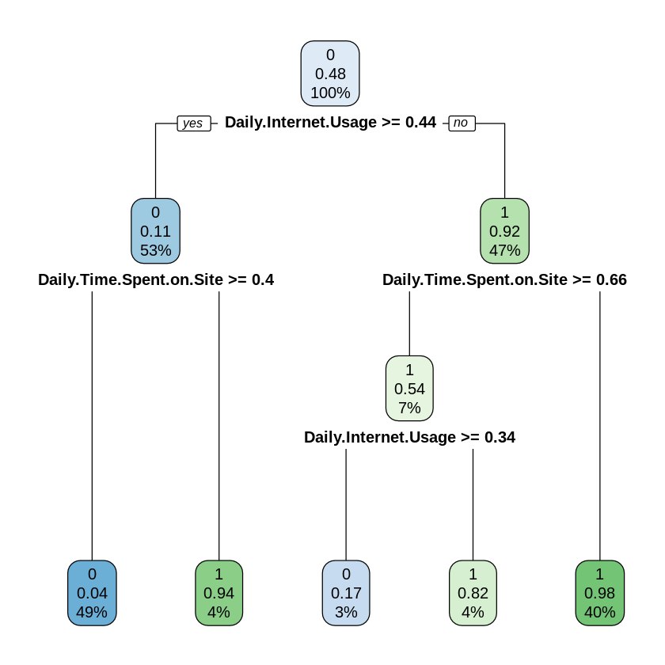

```python
# Fitting the decision tree model

install.packages('tree')
library(tree)

model <- rpart(Clicked.on.Ad~., data = data_train, method = 'class')
rpart.plot(model)

# Visualizing the model

rpart.plot(model)
```

```python
# Making a prediction on the test data

predict_unseen <-predict(fit, data_test, type = 'class')

table_mat <- table(data_test$Clicked.on.Ad, predict_unseen)
table_mat
```

[output not shown]

- The model accurately predicted 85 users who did not click on the ad and 104 users who clicked on the ad. The total number of incorrect predictions is 11. This a fairly good prediction model.

```python
# Calculating the accuracy score of the model

accuracy_score <- sum(diag(table_mat)) / sum(table_mat)

accuracy_score
```

0.945

- The model has an accuracy of 94.5%. This high prediction value is quite acceptable since we do not want the model to overfit.

Hyperparameter Tuning to Optimize the Model

```python
# Adjusting the maximum depth as well as minimum  sample of a node

accuracy_tune <- function(fit) {
    predict_unseen <- predict(fit, data_test, type = 'class')
    table_mat <- table(data_test$Clicked.on.Ad, predict_unseen)
    accuracy_Test <- sum(diag(table_mat)) / sum(table_mat)
    accuracy_Test
}

control <- rpart.control(minsplit = 4,
    minbucket = round(5 / 3),
    maxdepth = 3,
    cp = 0)
tune_fit <- rpart(Clicked.on.Ad~., data = data_train, method = 'class', control = control)
accuracy_tune(tune_fit)
```

0.95

- Performing hyperparameter tuning improves the model performance slightly by 0.5%

# Conclusion and Recommendations

From the above analysis, below are some of the conclusions and recommendations that were obtained from data exploration (EDA):

- There is no need to have a time threshold before one can view the course advertisement on the blog. This is because most users who spent a relatively short time on the blog clicked on a previous similar ad.
- Users who are relatively older (above 50) are most likely to click on the ad. The advertisement can therefore target that age group more compared to other age groups.
- Low income areas should still be included in the target group of the ad since users in that income bracket are most likely to view the advertisement. Areas that experience low internet usage should also be included in the target audience.

In terms of predicting blog users who are likely to click on a course advertisement, Desicion Tree Classifier provides a descent model with a high prediction accuracy. However, other machine learning algorithms such as SVM and Random Forests can be investigated to further challenge the solution provided in this analysis.